# NPS – Adopting tipping-point theory to transcriptome profiles to unravel disease regulatory trajectory

Zhezhen Wang, Biniam Feleke and Xinan H.Yang

07/26/2019

Abstract

Network perturbation signature (NPS). The purpose of this R package NPS, is to analyze clinical transcriptome data in order to determine critical transition from phenotype-defined sample states. Fundamental of the tipping-point is applied to transcriptomic profiles where highly connected transcriptional configurations serve as attractors [1]. NPS improves on a method called Dynamic Network Biomarker (DNB) that was calculated within each state [2]. When studying NB, expressional patterns are often the aggregates of multiple dynamic subsystems and thus a new method is needed to allow for cross-state comparisons. This makes it vague to use DNB for tipping-point detection because the autocorrelation of non-DNB-modules at other states could attribute to an even higher DNB-score at a predicted ‘tipping point’ (Figure 1). By incorporating an index of critical state transition (IC-score) [3] into the DNB model, NPS overcomes this pitfall by checking for drastic deviations across samples around the tipping point. Thus, the NPS scheme acts as a hybrid model to join the advantages of both DNB and IC-scoring.

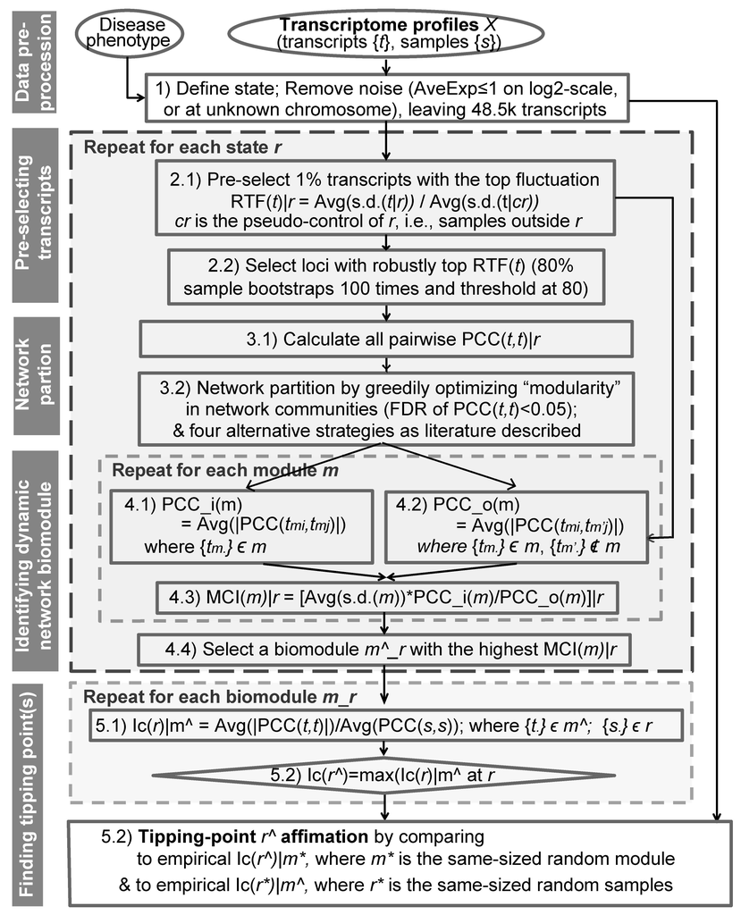

Fig 1. NPS workflow with five key analytic steps

#### Standard workflow

##### Transcript Annotation and Biotype

##### Quick Start

##### Genomic Data Source

##### Extracting Summary Data

##### Loading Data

##### Filtering chr21

##### An Identification of Critical Tipping Point

##### Data Preprocessing

##### Pre-selection Transcript

##### Network Partition

##### Identifying Dynamic Network Biomodule

##### Finding Tipping Point

##### Acknowledgements

##### SessionInfo

##### References

#### **Transcript Annotation and Biotype**

#### **Quick Start**

The R function getBiotype is used to group transcripts of interest into 11 biotypes based on GENCODE annotation (Fig 2a). When a query transcript overlaps at least half with a GENCODE transcript on the same strand, this query transcript will inherit the biotype of the GENCODE transcript.

First start by loading the required libraries: “GenomeInfoDb,” “NPS,” “GenomicRanges,” “IRanges” and “NPS”. Next load the datasets: “gencode”, “ILEF”, “intron” and “cod”. Using these datasets, excute NPS functions getBiotypes and getReadthrough as follows. These steps assume you installed the “NPS” package. If you did not install the package, use the `install.packages("NPS")` to install in R.

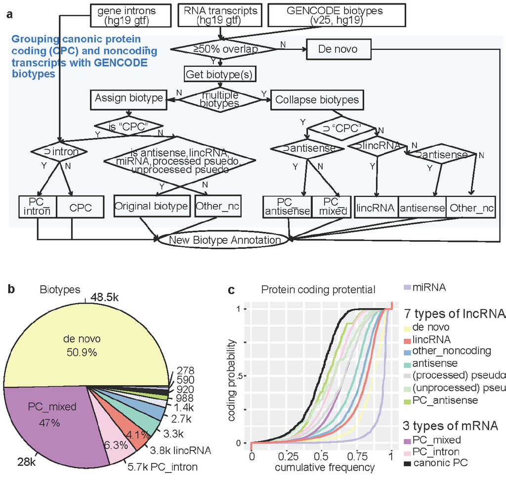

Fig 2. A getBiotypes workflow and protein-coding potential in real data analysis [4]. (a) Workflow of an in-house R function (getBiotypes) to query transcripts of interests and classify into biotypes. (b) Pie-chart of eleven types of transcripts assembled from polyadenylated RNA(TARGET). (c) Empirical cumulative distribution plot comparing the transcripts across all 11 biotypes. The protein-coding potential was estimated with the Coding Potential Assessment Tool (CPAT). Line color codes biotypes. The more a line towards the right-bottom corner, the lower protein-coding potential it has.

```r
#library("GenomeInfoDb")
#library("GenomicRanges")
#library("IRanges")
#library("NPS")
#data("gencode")
#head(gencode)
```

These illustrations above assumes you have installed “NPS” package. If you did not install the pacakge, use the `install.packages("NPS")` to install in R.

#### **Genomic Data Source**

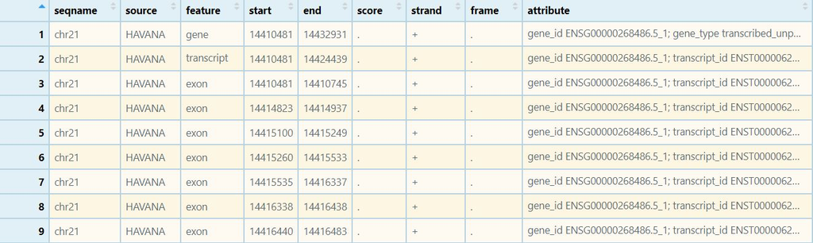

Chromosome 21 of human GRCh37 gtf

The table above shows head of chr21 dataset which was extracted from a full genome dataset GRCh37. The extraction of subset Chr21 is described below.

GoTop

##### **Extracting Summary Data**

Before any further analysis, we need to summarize the content of the raw gtf data. There are two ways to get genome biotypes: a) “transctipt_type” b) “gene_type”. Due to our interst in coding and noncoding regions, the `transcript_type` method was used to extract the regions of interest using python script shown below. **Note** that the `"PATH_FILE"` refers to the path where the downloded gtf file is located. For instance, if the gtf file is located on your `desktop`, replace the `"PATH_FILE"` with `"Users/user/Desktop/gtf"`.

**Python codes:**

```r
gtf = ("PATH_FILE")
outF = open("gtf_summary_transbiotype.txt","w")

def getquote(str,f,target):
    targetLen = len(target)+2
    strInd = str.find(target)
    st = strInd + len(target)+2
    ed = st + str[st:].find("";")
    #print(st,ed)
    f.write("\t"+str[st:ed]) if strInd!= -1 else f.write("\t"+"NA.")

with open(gtf, "r") as f:
     for line in f:
        if line[0] != "#":
            chromosome = line.split("\t")[0]
            st = line.split("\t")[3]
            ed = line.split("\t")[4]
            strand = line.split("\t")[6]
            type = line.split("\t")[2]
            outF.write(chromosome+"\t"+st+"\t"+ed+"\t"+strand+"\t"+type)
            c = "transcript_id"
            g = "gene_name"
            t = "transcript_type"
            getquote(line,outF,c)
            getquote(line,outF,g)
            getquote(line,outF,t)
            outF.write("\n")
outF.close()
```

GoTop

#### **Loading Data**

In order to load your data from a local drive, use the following format. **Note** that the `"PATH_FILE"` refers to the location of the summary data from the above section. For more details on how to load datasets click [here](https://support.rstudio.com/hc/en-us/articles/218611977-Importing-Data-with-RStudio)

##### loading data from local drive

> data <- read.delim(“PATH_FILE”, comment.char = “#”)

Internal NPS package data is included in the data folder. The data can be loaded into R working console using `data()` function. Here we show an example of how to load a dataset `gencode` from the data directory. A quick view of the data can be achieved using `head(gencode)`.

```r
#library("GenomeInfoDb")
library("GenomicRanges")
#library("IRanges")
#library("NPS")
data("gencode")
#head(gencode)
```

GoTop

#### **Filtering chr21**

Here we show an extraction of “gencode” dataset using R commands. Note to replace `PATH_FILE` with file direcotry path. `gtf` refers to the full genome file. A subset function was used to filter chr21 dataset as follows.

`chr21 <- subset(gencode, seqnames == "chr21")` #“genecode” = whole genome gtf

```
> gtf = read.table("PATH_FILE")
> gtf = subset(gtf, biotype == "transcript")
> colnames(gtf) = c("chr","start","end","strand","biotype")
> gr = GRanges(gtf)
```

GoTop

#### **Examples**

##### Processing Query

```r
query <- GRanges(c("chr1:2-10:+","chr1:6-10:-"), Row.names = c("trans1","trans2"),score = c(1,2))
head(query)
```

```
## GRanges object with 2 ranges and 2 metadata columns:
##       seqnames    ranges strand |   Row.names     score
##          <Rle> <IRanges>  <Rle> | <character> <numeric>
##   [1]     chr1      2-10      + |      trans1         1
##   [2]     chr1      6-10      - |      trans2         2
##   -------
##   seqinfo: 1 sequence from an unspecified genome; no seqlengths
```

##### Classifying Biotypes

```r
#library(NPS)
#library("GenomeInfoDb")
#library("GenomicRanges")
#library("IRanges")
gr <- GRanges(c("chr1:1-5:+","chr1:2-3:+"),biotype = c("lincRNA","CPC"))
head(gr)
```

```
## GRanges object with 2 ranges and 1 metadata column:
##       seqnames    ranges strand |     biotype
##          <Rle> <IRanges>  <Rle> | <character>
##   [1]     chr1       1-5      + |     lincRNA
##   [2]     chr1       2-3      + |         CPC
##   -------
##   seqinfo: 1 sequence from an unspecified genome; no seqlengths
```

##### Extracting intron coordinates

```
  # Intron coordinates

   intron <- GRanges("chr1:6-8:+")
```

```r
#library(NPS)
#library("GenomeInfoDb")
#library("GenomicRanges")
#library("IRanges")

intron <- GRanges("chr1:6-8:+")
head(intron)
```

```
## GRanges object with 1 range and 0 metadata columns:
##       seqnames    ranges strand
##          <Rle> <IRanges>  <Rle>
##   [1]     chr1       6-8      +
##   -------
##   seqinfo: 1 sequence from an unspecified genome; no seqlengths
```

##### Filtering coding transcripts

```
# Filtering non-coding regions using products from example 1, 2 and 3
```

```r
#library("NPS")
#library("GenomeInfoDb")
#library("GenomicRanges")
#library("IRanges")

#intron_trncp <- getBiotypes(query, gr, intron)
#intron_trncp
```

```
# Filtering Intron and Exons
```

Here we show how to obtain protien coding and non-coding from our datasets. The coding transcrptis are an expressed sections of the genome that is responsibe for protein fomation. Meanwhile the non-coding transcripts are vital in the fromation reguraltory elements such promoters, enhancers and silencers.

```r
#library("NPS")
library("GenomeInfoDb")
library("GenomicRanges")
library("IRanges")
#data("intron")
#data("ILEF")
#data("gencode")
#gencode_gr = GRanges(gencode)
#ILEF_gr = GRanges(ILEF)
#cod_gr = GRanges(cod)
#intron_gr = GRanges(intron)

#non-coding <- getBiotypes(ILEF_gr, gencode_gr, intron_gr)
#non-coding
#
#coding <- getBiotypes(ILEF_gr, gencode_gr)
#coding
```

##### Finding overlapping transcripts

```
# Samples with overlapping coding regions.
```

```r
#library("NPS")
#library("GenomicRanges")
#library("IRanges")
#library("GenomeInfoDb")

data("ILEF")
data("cod")
#ILEF_gr = GRanges(ILEF)
#cod_gr = GRanges(cod)

#rdthrough <- getReadthrough(ILEF_gr, cod_gr)
#rdthrough
```

#### **An Identification of Critical Tipping Point**

#### **Data Preprocessing**

#### **Pre-selection Transcript**

#### **Network Partition**

#### **Identifying Dynamic Network Biomodule**

#### **Finding Tipping Point**

Next we will filter clinical data and group the transcripts into five different stages of disease progression: `"activated"`, `"lymphoma_aggressive"`, `"lymphoma_marginal"`, `"lymphoma_transitional,"` and `"resting"` as disease stage names. These stages resemble the general disease progression patterns: normal(healthy) state, predisease state, tipping point, critical transition stage(CTS) and disease stage. Currently it is vey difficult to identify when a disease progress from predisease state to critical transition state. In most cases these transitions occurs very fast. Ultimately we want to identify this critical tipping point before it progresses into a early disease stage.

An existing dataset, GSE6136, is used to demonestrate how our functions are applied. Start by loading packages “stringr”, “psych”, “igraph” and “cluster”. If these packages are not installed, use the `install.packages("packages")` function to install them. Then load them using `library("package")`. Below are some examples.

```r
#install.packages("stringr")
library("stringr")
library("psych")
```

```r
library("igraph")
library("cluster")
```

```r
source("C:/Users/benjk/Desktop/NPS/R/NPS.R")
GSE6136 = read.table("C:/Users/benjk/Desktop/GSE6136_matrix.txt", header = TRUE, comment = "!")

dim(GSE6136)               #[1] 22690rows and 27 columns
```

```
## [1] 22690    27
```

```r
row.names(GSE6136) = GSE6136$ID_REF
GSE6136 = GSE6136[,-1]
dim(GSE6136)               #[1] 22690 rows and 26 columns
```

```
## [1] 22690    26
```

The summary of GSE6136 dataset is shown below.

```r
cli = read.delim("C:/Users/benjk/Desktop/GSE6136_cli.txt", head = F)
dim(cli)
```

```
## [1] 36 27
```

```r
cli = t(cli)
colnames(cli) = str_split_fixed(cli[1,],'_',2)[,2]
cli = cli[-1,]
cli = data.frame(cli)
cli[,"cell-type:ch1"] = str_split_fixed(cli$characteristics_ch1.1,": ",2)[,2]
cli[,"Ig clonality:ch1"] = str_split_fixed(cli$characteristics_ch1.3,": ",2)[,2]

colnames(cli)[colnames(cli) == "cell-type:ch1"] = "group"
cli$Row.names = cli[,1]
head(cli)
```

```
##    geo_accession                status submission_date last_update_date
## V2     GSM142398 Public on Oct 28 2006     Oct 25 2006      Mar 18 2009
## V3     GSM142399 Public on Oct 28 2006     Oct 25 2006      Mar 18 2009
## V4     GSM142400 Public on Oct 28 2006     Oct 25 2006      Mar 18 2009
## V5     GSM142401 Public on Oct 28 2006     Oct 25 2006      Mar 18 2009
## V6     GSM142402 Public on Oct 28 2006     Oct 25 2006      Mar 18 2009
## V7     GSM142403 Public on Oct 28 2006     Oct 25 2006      Mar 18 2009
##    type channel_count                      source_name_ch1 organism_ch1
## V2  RNA             1             wildtype resting B-Cells Mus musculus
## V3  RNA             1           wildtype activated B-Cells Mus musculus
## V4  RNA             1            E-mu-BRD2 resting B-Cells Mus musculus
## V5  RNA             1            E-mu-BRD2 resting B-Cells Mus musculus
## V6  RNA             1 marginal E-mu-BRD2 mediated lymphoma Mus musculus
## V7  RNA             1 marginal E-mu-BRD2 mediated lymphoma Mus musculus
##    characteristics_ch1        characteristics_ch1.1  characteristics_ch1.2
## V2  genotype: wildtype           cell-type: resting     splenomegaly: none
## V3  genotype: wildtype         cell-type: activated     splenomegaly: none
## V4 genotype: E-mu-BRD2           cell-type: resting     splenomegaly: none
## V5 genotype: E-mu-BRD2           cell-type: resting     splenomegaly: none
## V6 genotype: E-mu-BRD2 cell-type: lymphoma_marginal splenomegaly: marginal
## V7 genotype: E-mu-BRD2 cell-type: lymphoma_marginal     splenomegaly: mild
##        characteristics_ch1.3 molecule_ch1
## V2  Ig clonality: polyclonal    total RNA
## V3  Ig clonality: polyclonal    total RNA
## V4  Ig clonality: polyclonal    total RNA
## V5  Ig clonality: polyclonal    total RNA
## V6 Ig clonality: oligoclonal    total RNA
## V7 Ig clonality: oligoclonal    total RNA
##                                                                                                            extract_protocol_ch1
## V2 Total RNA was isolated with the guanidinium thiocyanate method, extracted with acid phenol and precipitated from 2-propanol.
## V3 Total RNA was isolated with the guanidinium thiocyanate method, extracted with acid phenol and precipitated from 2-propanol.
## V4 Total RNA was isolated with the guanidinium thiocyanate method, extracted with acid phenol and precipitated from 2-propanol.
## V5 Total RNA was isolated with the guanidinium thiocyanate method, extracted with acid phenol and precipitated from 2-propanol.
## V6 Total RNA was isolated with the guanidinium thiocyanate method, extracted with acid phenol and precipitated from 2-propanol.
## V7 Total RNA was isolated with the guanidinium thiocyanate method, extracted with acid phenol and precipitated from 2-propanol.
##    label_ch1
## V2    biotin
## V3    biotin
## V4    biotin
## V5    biotin
```

[output cut: 71 more lines]

```
## V7 http://gg.bu.edu
##                                                                   supplementary_file
## V2 ftp://ftp.ncbi.nlm.nih.gov/geo/samples/GSM142nnn/GSM142398/suppl/GSM142398.CEL.gz
## V3 ftp://ftp.ncbi.nlm.nih.gov/geo/samples/GSM142nnn/GSM142399/suppl/GSM142399.CEL.gz
## V4 ftp://ftp.ncbi.nlm.nih.gov/geo/samples/GSM142nnn/GSM142400/suppl/GSM142400.CEL.gz
## V5 ftp://ftp.ncbi.nlm.nih.gov/geo/samples/GSM142nnn/GSM142401/suppl/GSM142401.CEL.gz
## V6 ftp://ftp.ncbi.nlm.nih.gov/geo/samples/GSM142nnn/GSM142402/suppl/GSM142402.CEL.gz
## V7 ftp://ftp.ncbi.nlm.nih.gov/geo/samples/GSM142nnn/GSM142403/suppl/GSM142403.CEL.gz
##    data_row_count             group Ig clonality:ch1 Row.names
## V2          22690           resting       polyclonal GSM142398
## V3          22690         activated       polyclonal GSM142399
## V4          22690           resting       polyclonal GSM142400
## V5          22690           resting       polyclonal GSM142401
## V6          22690 lymphoma_marginal      oligoclonal GSM142402
## V7          22690 lymphoma_marginal      oligoclonal GSM142403
```

We normalized the expression of genes using log2() scale. This normalization will ensure a more accurate comparison of the variance between the expression groups (clusters).

```r
dat <- GSE6136
df <- log2(dat+1)
head(df)
```

```
##              GSM142398 GSM142399 GSM142400 GSM142401 GSM142402 GSM142403
## 1415670_at   10.219169 10.290480  9.987548 10.076816  9.827343  9.871289
## 1415671_at   10.903581 11.159934 10.776186 10.929998 11.468268 11.200408
## 1415672_at   11.115304 10.892087 11.091303 11.040290 11.109504 11.325305
## 1415673_at    8.990388 10.265615  8.742141  8.422065  8.963474  8.874674
## 1415674_a_at  9.911692 10.665869  9.942661  9.793766 10.243650 10.147078
## 1415675_at    9.524933  9.896332  9.590774  9.375474  9.392747  9.422065
##              GSM142404 GSM142405 GSM142406 GSM142407 GSM142408 GSM142409
## 1415670_at    9.675428  9.950702  9.848153 10.103419 10.040838  9.823367
## 1415671_at   10.654726 10.875135 10.854245 10.898450 10.736909 10.000000
## 1415672_at   11.639702 10.989253 11.021605 11.255088 11.278449 11.232960
## 1415673_at    8.923327  9.214562  8.965496  9.212861  9.121793  9.634993
## 1415674_a_at 10.133271 10.344962 10.392210 10.551131  9.750205 10.642864
## 1415675_at    9.396605  9.894666  9.818103  9.794741  9.857981 10.175924
##              GSM142410 GSM142411 GSM142412 GSM142413 GSM142414 GSM142415
## 1415670_at    9.974271 10.226412  9.471878  9.483413  9.743320 10.126317
## 1415671_at   10.341185 10.515897 10.486835 11.247394 10.813861 10.714589
## 1415672_at   11.227135 10.945444 10.904334 11.208173 11.316168 11.251542
## 1415673_at    9.696794  9.112440  9.050121  9.026523  8.806711  9.242221
## 1415674_a_at 10.239360 10.351381 10.469744  9.948075  9.760886 10.089980
## 1415675_at    9.603997  9.392532  9.250062  9.563387  9.597680  9.594325
##              GSM142416 GSM142417 GSM142418 GSM142419 GSM142420 GSM142421
## 1415670_at    9.654457  9.976134 10.033423  9.712699 10.093286  9.939138
## 1415671_at   10.429407 10.590681 10.663825 10.401733 10.812819 10.574026
## 1415672_at   10.418696 11.120108 11.484219 11.799808 11.337064 11.169048
## 1415673_at    8.240791 10.588715 10.380136 10.484521 10.616273  9.051209
## 1415674_a_at  9.813941 10.572984 10.664181 10.667023 10.865347  9.748696
## 1415675_at    8.961739  9.798634  9.638436  9.446670  9.690522  9.389739
##              GSM142422 GSM142423
## 1415670_at   10.152792  9.838258
## 1415671_at   10.615905 10.375908
## 1415672_at   11.469845 11.542500
## 1415673_at    9.899055 10.382732
## 1415674_a_at  9.434003  9.690696
## 1415675_at    9.111657  9.116084
```

```r
tmp <- names(table(cli$group))
samplesL <- split(cli[,1],f = cli$group)
head(samplesL)
```

```
## $activated
##        V3       V26       V27
## GSM142399 GSM142422 GSM142423
## 26 Levels: GSM142398 GSM142399 GSM142400 GSM142401 GSM142402 ... GSM142423
##
## $lymphoma_aggressive
##        V9       V10       V20       V21       V22       V23       V24
## GSM142405 GSM142406 GSM142416 GSM142417 GSM142418 GSM142419 GSM142420
## 26 Levels: GSM142398 GSM142399 GSM142400 GSM142401 GSM142402 ... GSM142423
##
## $lymphoma_marginal
##        V6        V7        V8       V11       V12       V13
## GSM142402 GSM142403 GSM142404 GSM142407 GSM142408 GSM142409
## 26 Levels: GSM142398 GSM142399 GSM142400 GSM142401 GSM142402 ... GSM142423
##
## $lymphoma_transitional
##       V14       V15       V16       V17       V18
## GSM142410 GSM142411 GSM142412 GSM142413 GSM142414
## 26 Levels: GSM142398 GSM142399 GSM142400 GSM142401 GSM142402 ... GSM142423
##
## $resting
##        V2        V4        V5       V19       V25
## GSM142398 GSM142400 GSM142401 GSM142415 GSM142421
## 26 Levels: GSM142398 GSM142399 GSM142400 GSM142401 GSM142402 ... GSM142423
```

```r
test <- sd_selection(df, samplesL,0.01)
head(test[["activated"]])
```

```
##              GSM142399 GSM142422 GSM142423
## 1415766_at    7.600656  8.778077  9.036723
## 1415827_a_at 11.002252 13.079218 13.205503
## 1415904_at   12.229810  5.885086  4.217231
## 1415985_at   11.786106 10.736656 10.044940
## 1416034_at   11.417114 13.474682 13.760252
## 1416071_at   11.194388 10.362273  9.993646
```

A graphical represetation of genes of interest can be achieved using the functions shown below. The `getNetwork` function will obtain an igraph object based on a pearson correlation of `test`. This `igraphL` object is then run using the `getCluster_methods` function classify nodes.

```r
igraphL <- getNetwork(test, fdr = 0.05)
```

```
## [1] "activated:7 nodes"
## [1] "lymphoma_aggressive:218 nodes"
## [1] "lymphoma_marginal:0 nodes"
## [1] "lymphoma_transitional:181 nodes"
## [1] "resting:0 nodes"
```

```r
#summary(igraphL)
clstr <- getCluster_methods(igraphL)
#summary(clstr)
head(clstr)
```

```
## $activated
## IGRAPH clustering walktrap, groups: 3, mod: 0.56
## + groups:
##   $`1`
##   [1] "1418580_at" "1419357_at"
##
##   $`2`
##   [1] "1416632_at"   "1428476_a_at" "1449553_at"
##
##   $`3`
##   [1] "1416930_at"   "1422032_a_at"
##
##
## $lymphoma_aggressive
## IGRAPH clustering walktrap, groups: 6, mod: 0.33
## + groups:
##   $`1`
##    [1] "1416001_a_at" "1416002_x_at" "1416527_at"   "1416754_at"
##    [5] "1416771_at"   "1417133_at"   "1417237_at"   "1417435_at"
##    [9] "1417570_at"   "1417604_at"   "1417634_at"   "1417720_at"
##   [13] "1417730_at"   "1417826_at"   "1417839_at"   "1418563_at"
##   [17] "1418718_at"   "1418902_at"   "1419149_at"   "1419259_at"
##   [21] "1419469_at"   "1419657_a_at" "1419997_at"   "1420553_x_at"
##   [25] "1420897_at"   "1421066_at"   "1422181_at"   "1422466_at"
##   [29] "1422823_at"   "1422824_s_at" "1423266_at"   "1423438_at"
##   [33] "1423841_at"   "1423909_at"   "1424033_at"   "1424072_at"
##   + ... omitted several groups/vertices
##
## $lymphoma_marginal
## [1] NA
##
## $lymphoma_transitional
## IGRAPH clustering walktrap, groups: 30, mod: 0.34
## + groups:
##   $`1`
##   [1] "1417866_at" "1424822_at" "1426957_at"
##
##   $`2`
##    [1] "1416246_a_at" "1416950_at"   "1416992_at"   "1417111_at"
##    [5] "1417640_at"   "1417930_at"   "1418842_at"   "1419104_at"
##    [9] "1421922_at"   "1423226_at"   "1423526_at"   "1423829_at"
##   [13] "1423946_at"   "1425553_s_at" "1429563_x_at" "1434883_at"
##   [17] "1448511_at"   "1448904_at"   "1450355_a_at" "1452132_at"
##   [21] "1452430_s_at" "1452431_s_at" "1460188_at"   "1460407_at"
##   + ... omitted several groups/vertices
##
## $resting
## [1] NA
```

```r
#par(mfrow <- c(1,5))
#membersL_noweight <- getMCI(cluster, test, adjust.size = F, ylim = c(0,8))
#head(getMCI)
#maxCIms <- getMaxCImember(membersL_noweight[[1]],membersL_noweight[[2]],min =3)
#head(maxCIms)
```

GoTop

#### **Acknowledgements**

The development of this package would not be possible without continous help and feedback from individuals and institutions including: The Bioconductor Core Team, Dr. Xianan H Yang, Dr. Tzintzuni Garcia, and National Institutes of Health R21LM012619.

GoTop

GoTop

#### **References**

1. Scheffer M, Carpenter SR, Lenton TM, Bascompte J, Brock W, Dakos V, et al. Anticipating critical transitions. Science. 2012;338(6105):344-8. doi: 10.1126/science.1225244. PubMed PMID: 23087241.
2. Chen L, Liu R, Liu ZP, Li M, Aihara K. Detecting early-warning signals for sudden deterioration of complex diseases by dynamical network biomarkers. Sci Rep. 2012;2:342. Epub 2012/03/31. doi: 10.1038/srep00342. PubMed PMID: 22461973; PubMed Central PMCID: PMC3314989.
3. Mojtahedi M, Skupin A, Zhou J, Castano IG, Leong-Quong RY, Chang H, et al. Cell Fate Decision as High-Dimensional Critical State Transition. PLoS Biol. 2016;14(12):e2000640. doi: 10.1371/journal.pbio.2000640. PubMed PMID: 28027308; PubMed Central PMCID: PMCPMC5189937.
4. Wang ZZ, Cunningham JM, Yang XH. CisPi: a transcriptomic score for disclosing cis-acting disease-associated lincRNAs. Bioinformatics. 2018;34(17):664-70. doi: 10.1093/bioinformatics/bty574. PubMed PMID: WOS:000444317200009.